# New York City Data Science Challenge

## 1. Metric Definition (4 hours)

#### Propose a metric or algorithm to assess the **efficiency** of a set of rides, given the available data sources. Make realistic assumptions and necessary simplifications and state them.

The first step we should make is to understand the definition of efficiency in order to apply it correctly on our case. Asking Google about it, we can understand efficiency as [**the ratio of the useful work performed by a machine or in a process to the total energy expended or heat taken in**](https://www.google.com/search?q=efficiency+definition), so we have the task of proposing a measure for the ratio of useful work in a set of taxi rides. There are two different points of view with different objectives regarding the meaning of the mentioned ratio (depending on the final user of the efficiency metric):

- Taxi Drivers/Management Companies - Maximize benefits of the service and minimize costs
- Taxi Users/Regulators - Minimize costs and maximize service quality

It seems reasonable that minimize costs is the shared objective from both perspectives, but meanwhile the driver POV is prioritizing the benefit over the service quality (it doesn't mean that the driver has no interest on the service quality), the taxi user will be always focusing on the latter first. Reaching this point, we should be giving a glimpse to the available data sources in order to see whether we can design a feasible metric following the two types of users.

The NYC Taxi & Limousine Commission hands a dictionary for each ride type, but as we'll see in the second section, we will be only focusing on the [*Yellow Taxi Trips*](https://www1.nyc.gov/assets/tlc/downloads/pdf/data_dictionary_trip_records_yellow.pdf). These are the variables included in the dataset:

- Taxicab Technology Service Provider (TPEP)
- Pickup/Dropoff datetimes
- Pickup/Dropoff locations
- Passenger count
- Trip distance
- Rate fare code
- Trip record sending condition
- Payment type
- Fare/extras/taxes/toll/tip/total amounts

There are a couple of key variables missing in order to correctly design a driver-relevant metric: taxi ID and taxi route. Without them it's easier to develop a user-relevant metric. We must do the exercise of study the possibilities of these variables regarding the "Minimize costs and maximize service quality". If we want to **minimize costs** we must get a good grip on how the taxi fare is calculated. As stated in the [NYC website](https://www1.nyc.gov/site/tlc/passengers/taxi-fare.page), the standard taxi fare ($RateCodeID = 1$) is time-and-distance dependant:

$ ExpectedFare = 2,5 + 2,5 * Distance + 120 * TravelTime $

It should be noted that the $Distance$ (in miles) fare is only applied when travelling over 12 mph, and the $TravelTime$ (in seconds) is applied only below 12 mph (slow mode). This is a problem for us because we have no way to check the speed distribution of each ride, so we must make the first simplification in order to continue the study. We will consider that the $Distance$ fare is always applied (independently of the speed). This will allow us to check the percentage of the travel that was performed on the "slow-mode" ($SlowModePercent$) as we can compare the theoretical fare against the real fare amount with the following formula:

$ SlowModePercent = \frac{120 * (FareAmount - ExpectedFare)}{TravelTime} * 100 $

The greater this value gets, the less efficient the ride will be as the drive hasn't been able to choose the best path in order to minimize the ride cost. Although we can think that this $SlowModePercent$ will vary homogeneously between 0 and 100, there is enough [evidence](https://www.nyc.gov/html/dot/downloads/pdf/mobility-report-2018-screen-optimized.pdf) that states the yellow taxi speed average in New York is below the 12 mph threshold. We have then to be quite cautious when defining the formula that transforms the percentage into the efficiency metric, so we will have to wait until the data analysis is done to do so ($f$).

There is also a couple of extra assumptions we must make in order to make this work regarding the Pickup/Dropoff datetimes and the Rate fare. The dictionary says that these datetimes are related to when the meter is engaged/disengaged, but we'll assume that those datetimes are the start/end of each ride. As we'll see later, most of the yellow taxi trips have the standard fare rate applied at the end of the trip ($RateCodeID = 1$), but we'll assume that the rate fare stated in this variable is applied during the whole trip, leaving the other rate fares out of this study.

Regarding the **maximize service quality** premise, there is a key variable in the dataset that can help us measure it, as we take the tip percentage paid by the taxi-user as a good measure of service satisfaction:

Finally, there is another variable that can be used in order to measure the efficiency from the regulator perspective. Nowadays, sustainability is one of the main drivers for nay service quality, so we should bonus those rides that enhance the sustainability of the taxi rides. Big cities like New Yok are affected by constant traffic jams, so the $PassengerCount$ should affect also the efficiency of the rides, because the higher this number is, the lower the impact on the NYC traffic will the ride have. We will also define in the next section the function to apply ($h$).

If we collect all the previous factors, we can build the proposed metric for the NYC taxi efficiency:

$ TaxiEfficiency = f(SlowModePercent) + g(TipPercentage) + h(PassengerCount)$

# 2. Metric Implementation (~16,5 hours)

#### Implement your proposed metric, and evaluate **Manhattan’s** overall efficiency using **yellow taxi data from the first full week (Monday-Sunday) in June 2016**. Discuss the complexity of your implementation.

In order to implement and evaluate the metric from the previous section, we'll structure the code in the following parts:

- **Load taxi trips dataset**
- **Filter the data by date**
- **Load the Manhattan shape**
- **Filter Manhattan trips**
- **Perform descriptive analysis**
- **Filter invalid data and outliers**
- **Implement efficiency metric**
- **Evaluate efficiency of the filtered dataset**

As we are working with a big Dataframe and we'll perform some intense operations, we'll make some backups in order to save time if we need further analysis in the future.

We'll start loading all the libraries needed to execute all the code below.

```python
import pandas as pd
import geopandas as gpd
from geopandas.tools import sjoin
import datetime as dt
import numpy as np
from scipy import stats
import matplotlib.pyplot as plt
import seaborn as sns

# Set the Seaborn theme for all the plots
sns.set_theme()
```

## Load taxi trips dataset (0,1 hours)

We can directly load the CSV from the NYC-TLC repository for the yellow taxi trips in June 2016, parsing directly the datetime variables.

```python
url_june16_data = "https://s3.amazonaws.com/nyc-tlc/trip+data/yellow_tripdata_2016-06.csv"
taxi_data = pd.read_csv(url_june16_data, parse_dates = [1, 2])
taxi_data.head()
```

|  | VendorID | tpep_pickup_datetime | tpep_dropoff_datetime | passenger_count | trip_distance | pickup_longitude | pickup_latitude | RatecodeID | store_and_fwd_flag | dropoff_longitude | dropoff_latitude | payment_type | fare_amount | extra | mta_tax | tip_amount | tolls_amount | improvement_surcharge | total_amount |
| --- | --- | --- | --- | --- | --- | --- | --- | --- | --- | --- | --- | --- | --- | --- | --- | --- | --- | --- | --- |
| 0 | 2 | 2016-06-09 21:06:36 | 2016-06-09 21:13:08 | 2 | 0.79 | -73.983360 | 40.760937 | 1 | N | -73.977463 | 40.753979 | 2 | 6.0 | 0.5 | 0.5 | 0.00 | 0.0 | 0.3 | 7.30 |
| 1 | 2 | 2016-06-09 21:06:36 | 2016-06-09 21:35:11 | 1 | 5.22 | -73.981720 | 40.736668 | 1 | N | -73.981636 | 40.670242 | 1 | 22.0 | 0.5 | 0.5 | 4.00 | 0.0 | 0.3 | 27.30 |
| 2 | 2 | 2016-06-09 21:06:36 | 2016-06-09 21:13:10 | 1 | 1.26 | -73.994316 | 40.751072 | 1 | N | -74.004234 | 40.742168 | 1 | 6.5 | 0.5 | 0.5 | 1.56 | 0.0 | 0.3 | 9.36 |
| 3 | 2 | 2016-06-09 21:06:36 | 2016-06-09 21:36:10 | 1 | 7.39 | -73.982361 | 40.773891 | 1 | N | -73.929466 | 40.851540 | 1 | 26.0 | 0.5 | 0.5 | 1.00 | 0.0 | 0.3 | 28.30 |
| 4 | 2 | 2016-06-09 21:06:36 | 2016-06-09 21:23:23 | 1 | 3.10 | -73.987106 | 40.733173 | 1 | N | -73.985909 | 40.766445 | 1 | 13.5 | 0.5 | 0.5 | 2.96 | 0.0 | 0.3 | 17.76 |

Before jumping to the time filtering, let's see the initial number of trips available on the dataframe and a quick analysis on the numerical variables. The output shows us that there are a couple of unexpected values in the variables _passenger*count*, _trip*distance*, *RatecodeID*, _fare*amount* and _total*amount* that must be cleaned at some point.

```python
taxi_data.shape[0]
```

```
11135470
```

```python
taxi_data.describe()
```

|  | VendorID | passenger_count | trip_distance | pickup_longitude | pickup_latitude | RatecodeID | dropoff_longitude | dropoff_latitude | payment_type | fare_amount | extra | mta_tax | tip_amount | tolls_amount | improvement_surcharge | total_amount |
| --- | --- | --- | --- | --- | --- | --- | --- | --- | --- | --- | --- | --- | --- | --- | --- | --- |
| count | 1.113547e+07 | 1.113547e+07 | 1.113547e+07 | 1.113547e+07 | 1.113547e+07 | 1.113547e+07 | 1.113547e+07 | 1.113547e+07 | 1.113547e+07 | 1.113547e+07 | 1.113547e+07 | 1.113547e+07 | 1.113547e+07 | 1.113547e+07 | 1.113547e+07 | 1.113547e+07 |
| mean | 1.529817e+00 | 1.657273e+00 | 3.044006e+00 | -7.305081e+01 | 4.024282e+01 | 1.043880e+00 | -7.312388e+01 | 4.028391e+01 | 1.349718e+00 | 1.350708e+01 | 3.407188e-01 | 4.973046e-01 | 1.842121e+00 | 3.402089e-01 | 2.996818e-01 | 1.683016e+01 |
| std | 4.991102e-01 | 1.302489e+00 | 2.183019e+01 | 8.208047e+00 | 4.521673e+00 | 5.660610e-01 | 7.880313e+00 | 4.341196e+00 | 4.944984e-01 | 2.755358e+02 | 5.339716e-01 | 4.451916e-02 | 2.713585e+00 | 1.719710e+00 | 1.358086e-02 | 2.758608e+02 |
| min | 1.000000e+00 | 0.000000e+00 | 0.000000e+00 | -1.181863e+02 | 0.000000e+00 | 1.000000e+00 | -1.181863e+02 | 0.000000e+00 | 1.000000e+00 | -4.500000e+02 | -4.123000e+01 | -2.700000e+00 | -6.770000e+01 | -1.250000e+01 | -3.000000e-01 | -4.508000e+02 |
| 25% | 1.000000e+00 | 1.000000e+00 | 1.000000e+00 | -7.399178e+01 | 4.073653e+01 | 1.000000e+00 | -7.399123e+01 | 4.073492e+01 | 1.000000e+00 | 6.500000e+00 | 0.000000e+00 | 5.000000e-01 | 0.000000e+00 | 0.000000e+00 | 3.000000e-01 | 8.800000e+00 |
| 50% | 2.000000e+00 | 1.000000e+00 | 1.710000e+00 | -7.398135e+01 | 4.075358e+01 | 1.000000e+00 | -7.397935e+01 | 4.075412e+01 | 1.000000e+00 | 1.000000e+01 | 0.000000e+00 | 5.000000e-01 | 1.350000e+00 | 0.000000e+00 | 3.000000e-01 | 1.230000e+01 |
| 75% | 2.000000e+00 | 2.000000e+00 | 3.230000e+00 | -7.396617e+01 | 4.076831e+01 | 1.000000e+00 | -7.396202e+01 | 4.076954e+01 | 2.000000e+00 | 1.550000e+01 | 5.000000e-01 | 5.000000e-01 | 2.460000e+00 | 0.000000e+00 | 3.000000e-01 | 1.836000e+01 |
| max | 2.000000e+00 | 9.000000e+00 | 7.173270e+04 | 0.000000e+00 | 6.409648e+01 | 9.900000e+01 | 1.062469e+02 | 6.004071e+01 | 5.000000e+00 | 6.285447e+05 | 5.979200e+02 | 6.035000e+01 | 8.548500e+02 | 9.700000e+02 | 1.164000e+01 | 6.290338e+05 |

## Filter the data by date (0,1 hours)

Checking June's 2016 calendar, it seems that the first complete week goes from **2016-06-06** to **2016-06-12**, so we'll apply that time filter for both _tpep_pickup*datetime* and _tpep_dropoff*datetime*. We'll check again the size of the time-filtered dataset.

```python
taxi_data = taxi_data.loc[(taxi_data["tpep_pickup_datetime"]  >= "2016-06-06") &
                          (taxi_data["tpep_pickup_datetime"]  <  "2016-06-13") &
                          (taxi_data["tpep_dropoff_datetime"] >= "2016-06-06") &
                          (taxi_data["tpep_dropoff_datetime"] <  "2016-06-13")]
taxi_data.reset_index(drop = True, inplace = True)
taxi_data.shape[0]
```

```
2624062
```

As the downloading takes some time, we'll make a backup for the time-filtered dataframe.

```python
taxi_data.to_csv("yellow_tripdata_2016-06-06_2016-06-12.csv", index = False)
```

## Load the Manhattan shape (0,5 hours)

Although the dictionary of the dataset states that the trips have the Location ID from the NYC Taxi Zones for both pickup/dropoff locations, in our case we have the exact lat/long coordinates for both locations, so we'll have to geoprocess each trip in order to check if both locations fall inside Manhattan borough. Considering that we've to perform more than 5M geoqueries, it's essential to optimize this section.

Exploring the Manhattan borough in a GIS, we can clearly see that the geometry is very complex and it's made from multiple polygons and a lot of points. One frequent way to optimize this problem is to create a grid of small rectangles on top of the original shape and then intersect it. Performing the same geoqueries over the new grid saves us a lot of time.

It's also important to choose a library that implements the RTree spatial indexing, so that's the main reason behind using *geopandas* functions.

Let's load both shapes and then plot them.

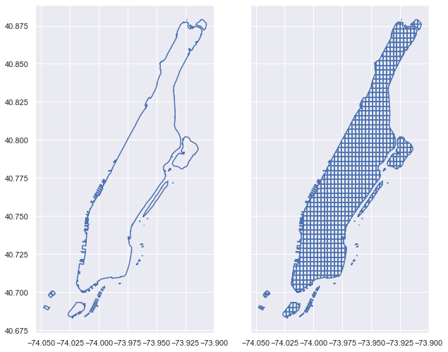

```python
borough_shape = gpd.GeoDataFrame.from_file("Borough Boundaries.geojson")
manhattan_grid_shape = gpd.GeoDataFrame.from_file("manhattan_grid_4e-3.geojson")

fig, (ax1, ax2) = plt.subplots(ncols = 2, sharex = True, sharey = True, figsize = (10, 10))
borough_shape.loc[[0],"geometry"].boundary.plot(ax = ax1)
manhattan_grid_shape.boundary.plot(ax = ax2)
```

## Filter Manhattan trips (4 hours)

If we already have the dataset in memory, we can skip the backup loading.

```python
if "taxi_data" not in locals():
    taxi_data = pd.read_csv("yellow_tripdata_2016-06-06_2016-06-12.csv", parse_dates = [1, 2])
```

In order to filter only the Manhattan trips, we must first create a geoDataFrame from the lat/long coordinate variables from the original DataFrame. We must also set the Coordinate Reference System as the one that is included in the Manhattan grid shape.

```python
pickup_points  = gpd.GeoDataFrame(geometry = gpd.points_from_xy(taxi_data["pickup_longitude"],
                                                                taxi_data["pickup_latitude"])
                                 ).set_crs(manhattan_grid_shape.crs)
dropoff_points = gpd.GeoDataFrame(geometry = gpd.points_from_xy(taxi_data["dropoff_longitude"],
                                                                taxi_data["dropoff_latitude"])
                                 ).set_crs(manhattan_grid_shape.crs)
```

We can then perform a *sjoin* operation to check which pickup and dropoff points fall inside Manhattan borough.

```python
pickup_manhattan = sjoin(pickup_points, manhattan_grid_shape, how = 'left')
dropoff_manhattan = sjoin(dropoff_points, manhattan_grid_shape, how = 'left')
```

We stated before that only the trips that start and end inside Manhattan are considered *Manhattan trips*, so we must drop any row that don't satisfy that condition. We'll check again the size of the zone-filtered dataset.

```python
no_manhattan = pickup_manhattan[pickup_manhattan["index_right"].isnull()].index.tolist() + \
               dropoff_manhattan[dropoff_manhattan["index_right"].isnull()].index.tolist()
# Drop duplicates from "no_manhattan" list
no_manhattan = list(dict.fromkeys(no_manhattan))
taxi_data = taxi_data.drop(no_manhattan)
taxi_data.reset_index(drop = True, inplace = True)
taxi_data.shape[0]
```

```
2167893
```

Once again, we make a backup for the zone-filtered dataframe.

```python
taxi_data.to_csv("yellow_tripdata_2016-06-06_2016-06-12_manhattan.csv", index = False)
```

## Perform descriptive analysis (3 hours)

If we already have the dataset in memory, we can skip the backup loading.

```python
if "taxi_data" not in locals():
    taxi_data = pd.read_csv("yellow_tripdata_2016-06-06_2016-06-12_manhattan.csv",
                            parse_dates = [1, 2])
```

### Pickup/Dropoff datetimes

Let's start the analysis adding the time delta between the pickup and the dropoff datetimes. Checking the boxplot graph, we can see that there are a good number of outliers on the high end that we have to address also, as it's not reasonable to have hour-like taxi trips inside Manhattan, as well as negative values that must be filtered out. There is another assumption we should make to normalize the trips for the next sections, as any ride that lasts less than 1 minute (60s) should be also considered anomalous and will be filtered out.

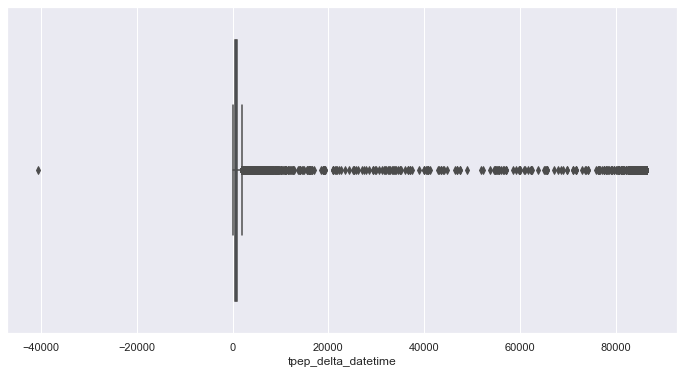

```python
taxi_data["tpep_delta_datetime"] = (taxi_data["tpep_dropoff_datetime"] -
                                    taxi_data["tpep_pickup_datetime"]).dt.total_seconds()

sns.set(rc = {"figure.figsize": (12, 6)})
ax = sns.boxplot(x = "tpep_delta_datetime", data = taxi_data)
```

```python
taxi_data[taxi_data["tpep_delta_datetime"] < 60].shape[0]
```

```
10802
```

### Trip distance

Repeating the boxplot over the _trip*distance* variable gives us the same conclusion: unreasonable long trips and some null distance trips that must be filtered.

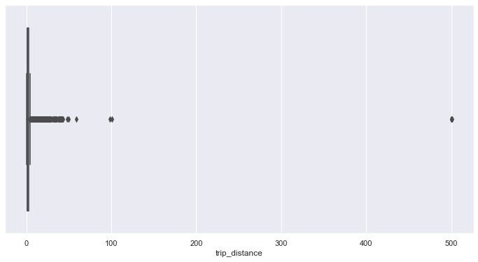

```python
sns.set(rc = {"figure.figsize": (12, 6)})
ax = sns.boxplot(x = "trip_distance", data = taxi_data)
```

```python
taxi_data[taxi_data["trip_distance"] == 0].shape[0]
```

```
6699
```

### Passenger count

Making a quick _value*counts()* on the _passenger*count* shows us that we have to filter 53 0s that must be also filtered.

```python
taxi_data["passenger_count"].value_counts()
```

```
1    1542472
2     309803
5     112559
3      90442
6      69701
4      42861
0         53
7          1
9          1
Name: passenger_count, dtype: int64
```

### Payment type

Viewing the _value*counts()* applied on the the _payment*type* shows us that we have to filter around 10k *No Charge* and *Dispute* values.

```python
taxi_data["payment_type"].value_counts()
```

```
1    1426300
2     731328
3       7593
4       2672
Name: payment_type, dtype: int64
```

### Average speed

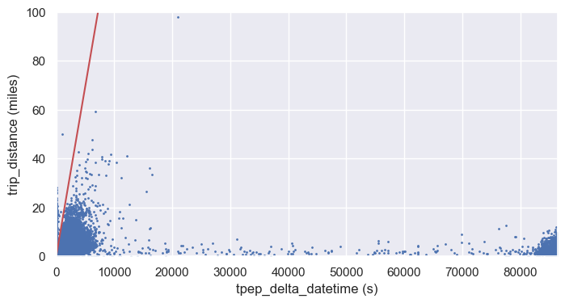

```python
plt.figure(figsize = (8, 4), dpi = 100)
plt.scatter(taxi_data["tpep_delta_datetime"], taxi_data["trip_distance"], s = 1)
speed_limit = np.linspace(0, int(max(taxi_data["tpep_delta_datetime"])), 1000)
plt.xlabel("tpep_delta_datetime (s)")
plt.ylabel("trip_distance (miles)")
plt.xlim([0, max(taxi_data["tpep_delta_datetime"])])
plt.ylim([0, 100])
plt.plot(speed_limit, 50*speed_limit/3600, color = "r");
plt.show()
```

### Fare amount/Tip percent

Considering that the initial chare in the standard fare rate is 2.5$, we should filter out all the 1k trips with the _fare*amount* below that point.

```python
taxi_data[taxi_data["fare_amount"] < 2.5].shape[0]
```

```
1152
```

We should be checking also into the _tip*percent* after calculating this new variable. In this case all the values appear to fall into the (0, 100) interval, but we should also filter out any trip that goes out from that value.

```
[(-10.0, 110.0)]
```

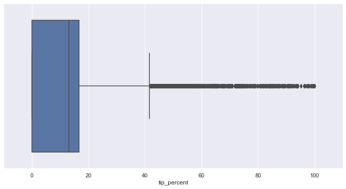

```python
taxi_data["tip_percent"] = taxi_data["tip_amount"] / taxi_data["total_amount"] * 100
sns.set(rc = {"figure.figsize": (12, 6)})
ax = sns.boxplot(x = "tip_percent", data = taxi_data)
ax.set(xlim = (-10, 110))
```

### Slowmode percentage

The other calculated variable that will be needed is the _slowmode*percent* that shows us how much time the taxi was in the "slowmode" during the trip. Checking the boxplot graph of this new variable shows us that we must filter every trip that skips the (0, 100) interval.

```
[(-10.0, 110.0)]
```

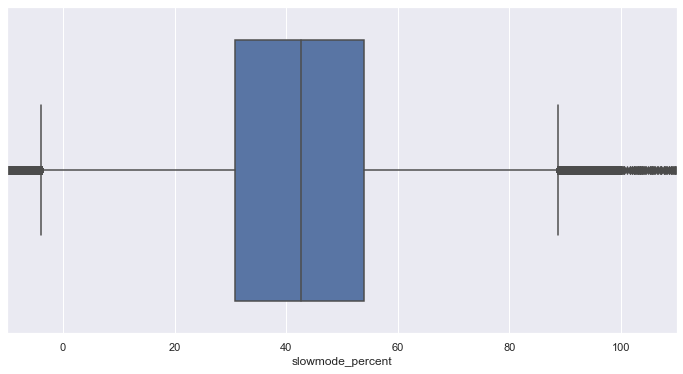

```python
taxi_data["slowmode_percent"] = ((taxi_data["fare_amount"] - (2.5 + (taxi_data["trip_distance"] * 5 / 2))) * 120) \
                                     / taxi_data["tpep_delta_datetime"] * 100
sns.set(rc = {"figure.figsize": (12, 6)})
ax = sns.boxplot(x = "slowmode_percent", data = taxi_data)
ax.set(xlim = (-10, 110))
```

Another way to check this is to represent the total time of the trip against the slowmode time calculated with the fare amount and the distance. This graph confirms us that a filter should be made in this direction.

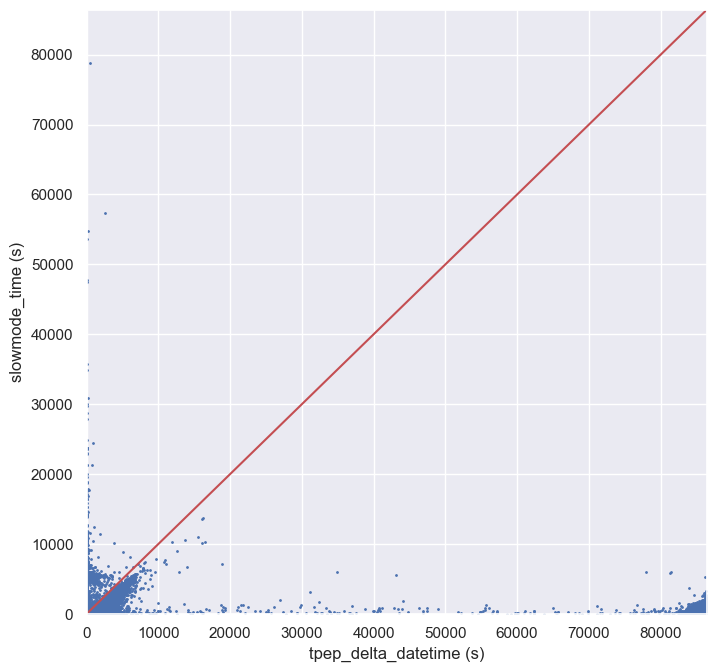

```python
plt.figure(figsize = (8, 8), dpi=100)
plt.scatter(taxi_data["tpep_delta_datetime"], (taxi_data["fare_amount"] - (2.5 + (taxi_data["trip_distance"] * 5 / 2))) * 120, s = 1)
slowmode_limit = np.linspace(0, int(max(taxi_data["tpep_delta_datetime"])), 1000)
plt.xlabel("tpep_delta_datetime (s)")
plt.ylabel("slowmode_time (s)")
plt.xlim([0, max(taxi_data["tpep_delta_datetime"])])
plt.ylim([0, max(taxi_data["tpep_delta_datetime"])])
plt.plot(slowmode_limit, slowmode_limit, color = "r");
plt.show()
```

## Filter invalid data and outliers (2 hours)

If we already have the dataset in memory, we can skip the backup loading.

```python
if "taxi_data" not in locals():
    taxi_data = pd.read_csv("yellow_tripdata_2016-06-06_2016-06-12_manhattan.csv",
                            parse_dates = [1, 2])
```

Considering all the conclusions from the last subsection, we can apply all the filter at once. We must also apply the filters that come from the assumptions we made at first. We'll check one more time the size of the value-filtered dataset.

```python
# Apply the assumptions for the rate fare and the payment type
taxi_data = taxi_data.loc[taxi_data["payment_type"] <= 2]
taxi_data = taxi_data.loc[taxi_data["RatecodeID"] == 1]
# Filter the trips with the fare below the initial charge
taxi_data = taxi_data.loc[taxi_data["fare_amount"] >= 2.5]
# Filter negative distance trips
taxi_data = taxi_data.loc[taxi_data["trip_distance"] > 0]
# Filter the trips with no passengers
taxi_data = taxi_data.loc[taxi_data["passenger_count"] > 0]
# Filter the trips above 50 mph
taxi_data = taxi_data.loc[(taxi_data["trip_distance"] / taxi_data["tpep_delta_datetime"] * 3600) <= 50]
# Filter slowmode_percent outside (0, 100) interval
taxi_data = taxi_data.loc[(taxi_data["slowmode_percent"] >= 0) & (taxi_data["slowmode_percent"] <= 100)]
# Filter tip_percent outside (0, 100) interval
taxi_data = taxi_data.loc[(taxi_data["tip_percent"] >= 0) & (taxi_data["tip_percent"] <= 100)]
# Filter the negative/short time trips
taxi_data = taxi_data.loc[taxi_data["tpep_delta_datetime"] >= 60]
# Filter the time and distance outliers
taxi_data = taxi_data.loc[(np.abs(stats.zscore(taxi_data["tpep_delta_datetime"])) < 3)]
taxi_data = taxi_data.loc[(np.abs(stats.zscore(taxi_data["trip_distance"])) < 3)]

taxi_data.reset_index(drop = True, inplace = True)
taxi_data.shape[0]
```

```
2062277
```

And we make the final backup for the value-filtered dataframe.

```python
taxi_data.to_csv("yellow_tripdata_2016-06-06_2016-06-12_manhattan_filtered.csv", index = False)
```

## Implement efficiency metric (5 hours)

If we already have the dataset in memory, we can skip the backup loading.

```python
if "taxi_data" not in locals():
    taxi_data = pd.read_csv("yellow_tripdata_2016-06-06_2016-06-12_manhattan_filtered.csv",
                            parse_dates = [1, 2])
```

Before jumping to the implementation, we should check whether the variables we want to include in the efficiency functions are correlated or not. As we are looking at values that fit into the (-1, 1) interval, these near 0 ensure that there is no direct correlation between the values of the three chosen variables (_slomode*percent*, _tip*percent* and _passenger*count*).

```python
print("corr(Slowmode percent - Passenger count) = " +
      str(np.round(taxi_data["slowmode_percent"].corr(taxi_data["passenger_count"]), 3)))
print("corr(Slowmode percent - Tip percent) = " +
      str(np.round(taxi_data["slowmode_percent"].corr(taxi_data["tip_percent"]), 3)))
print("corr(Tip percent - Passenger count) = " +
      str(np.round(taxi_data["tip_percent"].corr(taxi_data["passenger_count"]), 3)))
```

```
corr(Slowmode percent - Passenger count) = -0.008
corr(Slowmode percent - Tip percent) = -0.018
corr(Tip percent - Passenger count) = -0.02
```

Before going with the efficiency functions, we must make a final assumption related to its value domain. As it will be an efficiency metric used by taxi users and regulators, it seems logical to go with some interval easy to understand. This is the reason behind defining the domain value to [0, 5], as it were the "stars" we are used to in the review-like apps like Google Maps or TripAdvisor.

We must check again the value distribution for those three variables in order to implement a coherent function. We'll start with the _passenger*count* variable. The most frequent value (and the least sustainable) is 1, so the efficiency function shall grow when above the mean value. Therefore, the final function will have the following structure (based on a given $pc$ constant):

$$ h(passengerCount) = \begin{cases} -pc & \text{if } passengerCount = 1 \\ % & is your "\tab"-like command (it's a tab alignment character) 0 & \text{if } passengerCount = 2 \\ pc & \text{if } passengerCount \ge 3 \end{cases} $$

```
passenger_count mean value = 1.65
```

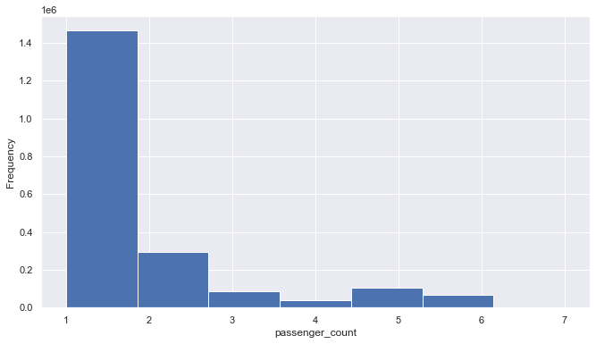

```python
print("passenger_count mean value = " + str(np.round(np.mean(taxi_data["passenger_count"]), 2)))
plt.figure(figsize = (11, 6))
plt.xlabel("passenger_count")
taxi_data["passenger_count"].plot.hist(bins = len(taxi_data["passenger_count"].value_counts()))
```

We must repeat now the same analysis for the _tip*percent* variable. In this case, it seems appropriate to represent a heatmap in order to check the distribution. As the _slowmode*percent* variable is defined between (0, 100), we will use it in this representation. As we stated in the first section, we should be careful with the _payment*type* variable because any cash tips are not included in the dataset. It seems that the standard tip rate is 16,6% from the total amount, so we will implement a function like the previous one (also based on a given $tc$ constant):

$$ g(tipPercent) = \begin{cases} -tc & \text{if } tipPercent < 16 \\ % & is your "\tab"-like command (it's a tab alignment character) 0 & \text{if } tipPercent \in [16, 17] \\ tc & \text{if } tipPercent > 17 \end{cases} $$

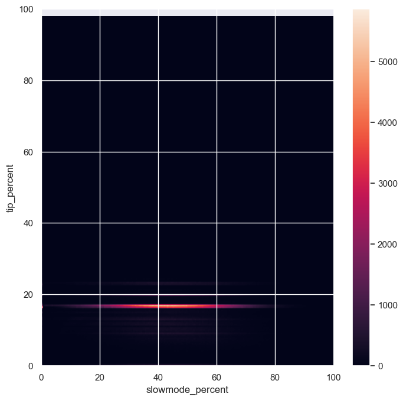

```python
# Filter the cash-paid trips
taxi_data_card = taxi_data.loc[taxi_data["payment_type"] == 1]
# Create the heatmap
heatmap, xedges, yedges = np.histogram2d(taxi_data_card["slowmode_percent"], taxi_data_card["tip_percent"], bins = 200)
extent = [xedges[0], xedges[-1], yedges[0], yedges[-1]]
plt.clf()
plt.figure(figsize = (8, 8), dpi=100)
plt.imshow(heatmap.T, extent = extent, origin = 'lower', aspect = 'auto')
plt.xlabel("slowmode_percent")
plt.xlim([0, 100])
plt.ylabel("tip_percent")
plt.ylim([0, 100])
plt.colorbar()
plt.show()
```

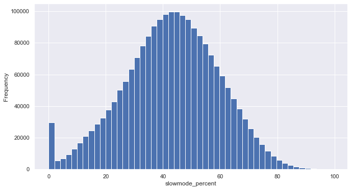

```python
plt.figure(figsize = (11, 6))
plt.xlabel("slowmode_percent")
taxi_data["slowmode_percent"].plot.hist(bins = 50)
```

```python
caca = taxi_data["slowmode_percent"].quantile(np.arange(0.025, 0.976, 0.095)).tolist()
```

```python
[caca[0], caca[-1]]
```

```
[7.9787234042553195, 73.78524295140971]
```

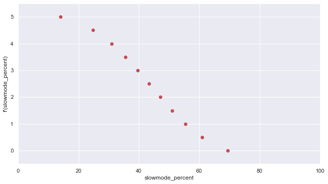

```python
# Create fitting points
x_fit = taxi_data["slowmode_percent"].quantile(np.arange(0.05, 0.96, 0.09)).tolist()
quantiles = [x_fit[0], x_fit[-1]]
y_fit = np.arange(5, -0.5, -0.5)
# Plot points
plt.figure(figsize = (11, 6))
plt.xlabel("slowmode_percent")
plt.xlim([0, 100])
plt.ylabel("f'(slowmode_percent)")
plt.ylim([-0.5, 5.5])
plt.plot(x_fit, y_fit, 'or')
```

We can now create the fitting polynomial equation and repeat the graph in order to check how the efficiency would like based on the _slowmode*percent* variable.

```
f'(x) = 5.002757757302801e-05*x^3 -0.006539504680291698*x^2 + 0.1560300672301933*x + 3.943012885971137
```

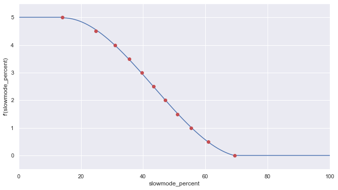

```python
# Fit the points and print the function
z_fit = np.polyfit(x_fit, y_fit, 3)
print("f'(x) = " + str(z_fit[0]) + "*x^3 " + str(z_fit[1]) +
      "*x^2 + " + str(z_fit[2])+ "*x + " + str(z_fit[3]))
# Draw function
plt.figure(figsize = (11, 6))
plt.xlabel("slowmode_percent")
plt.xlim([0, 100])
plt.ylabel("f'(slowmode_percent)")
plt.ylim([-0.5, 5.5])
plt.plot(np.linspace(min(x_fit), max(x_fit), 1000),
         np.polyval(z_fit, np.linspace(min(x_fit), max(x_fit), 1000)), "-b")
plt.plot(np.linspace(0, min(x_fit), 1000), np.linspace(5, 5, 1000), "-b")
plt.plot(np.linspace(max(x_fit), 100, 1000), np.linspace(0, 0, 1000), "-b")
plt.plot(x_fit, y_fit, "or")
```

With all this information, we must implement the function using the variables in a dataframe input and create a new column with the mentioned efficiency. After doing some tries, fixing the constant *tc* to 0.25 and *pc* to 0.1 give good results, but it's also an input that can be given to the function. We could also include the poly-fitting and the quantile operations inside the function but giving that the initial fitting exercise was made with a complete normal week, it should be a good representation of any yellow taxi ride similar dataset.

```python
def ride_efficiency(taxi_data, z_fit, quantiles, tc = 0.25, pc = 0.1):
    # Drop efficiency column if already exists
    if "efficiency" in taxi_data:
        taxi_data = taxi_data.drop(columns = "efficiency")
    # Init a empty vector
    effi_result = []
    # Iterate through the dataframe rows
    for index, row in taxi_data.iterrows():
        # Get the factor variables from the row
        slowmode_val = row["slowmode_percent"]
        tip_val = row["tip_percent"]
        passenger_val = row["passenger_count"]
        payment_val = row["payment_type"]
        # Estimate the efficiency from slowmode_percent factor
        if slowmode_val < quantiles[0]:
            effi_val = 5
        elif quantiles[0] <= slowmode_val < quantiles[1]:
            effi_val = max(min(np.polyval(z_fit, slowmode_val), 5), 0)
        else:
            effi_val = 0
        # Estimate the efficiency from tip_percent factor
        if (payment_val == 1) & (tip_val < 16):
            effi_val -= tc
        elif (payment_val == 1) & (tip_val > 17):
            effi_val += tc
        # Estimate the efficiency from passenger_count factor
        if passenger_val == 1:
            effi_val -= pc
        elif passenger_val > 2:
            effi_val += pc
        # Append the last result to the result vector
        effi_result.append(np.round(max(min(effi_val, 5), 0), 2))
    # Update the efficiency column with the final value
    taxi_data.insert(0, "efficiency", effi_result)

    return taxi_data
```

## Evaluate efficiency of the filtered dataset (2 hours)

It's now time to evaluate the complete filtered dataset with our new efficiency function and print the mean value. Considering all the descriptive analysis we made over the efficiency factors, it's reasonable to have an overall value near 2,5/5,0 (2,43 in this case).

```
Total Efficiency = 2.43 / 5.00
```

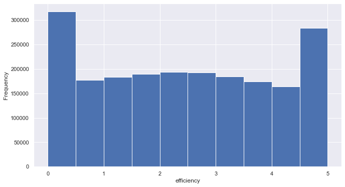

```python
taxi_data = ride_efficiency(taxi_data, z_fit, quantiles)
print("Total Efficiency = " + str(np.round(np.mean(taxi_data["efficiency"]), 2)) + " / 5.00")
plt.figure(figsize = (11, 6))
plt.xlabel("efficiency")
taxi_data["efficiency"].plot.hist()
```

In order to save tame to the following sections, we'll make a backup of the complete dataframe with the efficiency calculated.

```python
taxi_data.to_csv("yellow_tripdata_2016-06-06_2016-06-12_manhattan_filtered_efficiency.csv",
                 index = False)
```

# 3. Efficiency Variation (4 hours)

#### Based on the implementation in Question 2, use visualizations to show **how the efficiency metric varies** across different times of day, days of the week, or any other dimension you find interesting. Discuss potential business implications based on your findings.

If we already have the dataset in memory, we can skip the backup loading.

```python
if "taxi_data" not in locals():
    taxi_data = pd.read_csv("yellow_tripdata_2016-06-06_2016-06-12_manhattan_filtered_efficiency.csv",
                            parse_dates = [1, 2])
```

In order to check the variation across different times of day and days of the week, it's faster to calculate those time variables as new columns of our dataframe. We'll assume the _tpep_pickup*datetime* as the main date variable.

```python
taxi_data["tpep_weekday"] = taxi_data["tpep_pickup_datetime"].dt.dayofweek
taxi_data["tpep_dayhour"] = taxi_data["tpep_pickup_datetime"].dt.hour
```

### Time of day variation

Plotting the mean values for each hour of the day we can clearly see that there is a big variation between work hours and night hours. If we plot also the number of taxi trips recorded each hour, we can also see that the efficiency is directly affected by the drop on taxi records (after midnight and until 6am) and also by the high volume hours (from 8am until 5pm). We can also see that the yellow taxi trips are not the only type of traffic affecting Manhattan, as the rides peak at 7pm doesn't correspond with the lowest efficiency at 12pm. It can be more related to Manhattan activity as a city.

```
(0.0, 5.0)
```

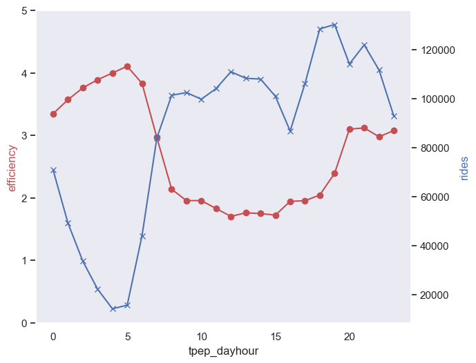

```python
# Init figure and axis
plt.figure(figsize = (6, 6))
fig, ax1 = plt.subplots(figsize = (7, 6), dpi = 100)
ax2 = ax1.twinx()
# Plot mean efficiency and the number of trips
ax1.plot(np.arange(0, 24), taxi_data.groupby("tpep_dayhour")["efficiency"].mean(), "r-o")
ax2.plot(np.arange(0, 24), taxi_data["tpep_dayhour"].value_counts(sort = False).tolist(), 'b-x')
ax1.grid(b = None)
ax2.grid(b = None)
ax1.set_xlabel("tpep_dayhour")
ax1.set_ylabel("efficiency", color = "r")
ax2.set_ylabel("rides", color = "b")
ax1.set_ylim([0, 5])
```

If we make boxplot graphs to the efficiency, we can also see that the variability of the result is greatly affected also by the hour of the day, getting more concentrated results early in the morning (3-6am), meanwhile the day gets very disperse results (8am-6pm). These results could be used by the users to check at which point of the day you should avoid getting a taxi ride because of the high-volume traffic and maybe look for an alternative transport method. The regulator could also use this information to adjust the fares and the restrictions affecting Manhattan in order to make the taxi a more efficient experience for the people.

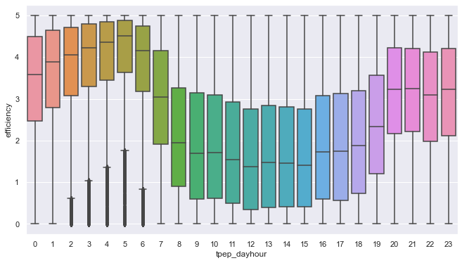

```python
sns.set(rc = {"figure.figsize": (11, 6)})
ax = sns.boxplot(x = "tpep_dayhour", y = "efficiency", data = taxi_data)
```

## Day of the week variation

```
(0.0, 5.0)
```

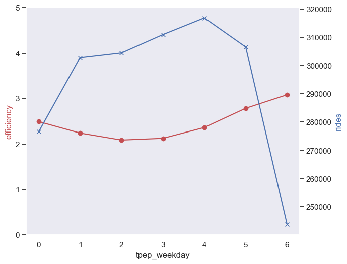

```python
# Init figure and axis
plt.figure(figsize = (6, 6))
fig, ax1 = plt.subplots(figsize = (7, 6), dpi = 100)
ax2 = ax1.twinx()
# Plot mean efficiency and the number of trips
ax1.plot(np.arange(0, 7), taxi_data.groupby("tpep_weekday")["efficiency"].mean(), "r-o")
ax2.plot(np.arange(0, 7), taxi_data["tpep_weekday"].value_counts(sort = False).tolist(), 'b-x')
ax1.grid(b = None)
ax2.grid(b = None)
ax1.set_xlabel("tpep_weekday")
ax1.set_ylabel("efficiency", color = "r")
ax2.set_ylabel("rides", color = "b")
ax1.set_ylim([0, 5])
```

Looking at the boxplot graph we can also confirm that the greater the mean efficiency gets, the smaller the variance comes. This conclusion is aligned to the one extracted from the previous variable.

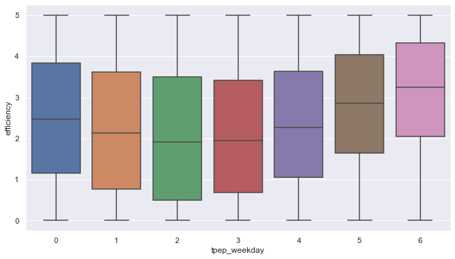

```python
sns.set(rc = {"figure.figsize": (11, 6)})
ax = sns.boxplot(x = "tpep_weekday", y = "efficiency", data = taxi_data)
```

## Other variables

We can start the analysis with the Vendor ID analysis in order to check if one of the companies is more efficient than the other. Although *Verifone Inc.* is a little more efficient, the difference is not enough in order to conclude so. This could also be related to the zones where the vendors' taxis are working in Manhattan.

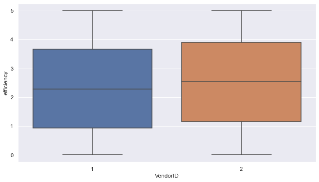

```python
sns.set(rc = {"figure.figsize": (11, 6)})
ax = sns.boxplot(x = "VendorID", y = "efficiency", data = taxi_data)
```

The *Trip record sending condition* shouldn't affect neither to the overall efficiency. The boxplot graph confirms this hypothesis. The small difference could be explained again by the dropoff location of the rides, as this flag is affected by the connection availability at that moment.

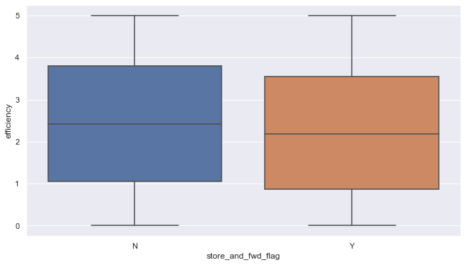

```python
sns.set(rc = {"figure.figsize": (11, 6)})
ax = sns.boxplot(x = "store_and_fwd_flag", y = "efficiency", data = taxi_data)
```

The same can be said about the _payment*type* variable. At first, we can think that the affection on the _tip*percent* function could affect the final efficiency values, but it seems that the function is correctly balanced to not affect at all.

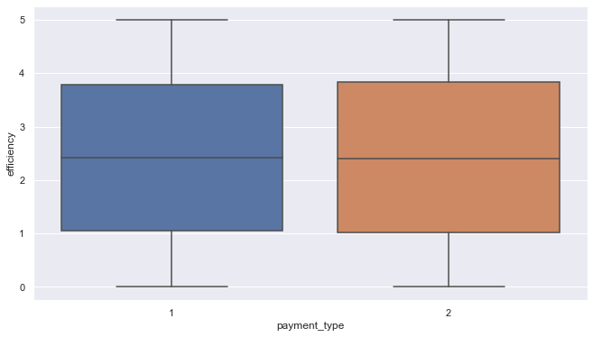

```python
sns.set(rc = {"figure.figsize": (11, 6)})
ax = sns.boxplot(x = "payment_type", y = "efficiency", data = taxi_data)
```

It seems that the zone-variation analysis could be the most important one because of the relation it has to the "congestion zones" in Manhattan. We will discuss it in the next section.

# 4. Zone Efficiency (1 hour)

#### **Answer the following question theoretically (no need to implement)**. Given the metric you proposed, how would you determine whether a specific zone is more efficient than the rest of the city? How would you determine why it’s more efficient?

Checking the data repository from the TLC, we can see that all the yellow-taxi-data after July 2016 has the ZoneID for the pickup and dropoff locations instead of the lat-long coordinates we handled during this exercise. This would soften the complexity of the implementation a lot, as we could perform directly a *groupBy* mean/median operation after calculating the efficiency for all the dataset (the same operation we made for the *weekday*/*dayhour* analysis in the last section).

Considering the data we have right now (lat-long coordinates), the operation we have to make is pretty similar as the one we did during the "Manhattan trip filtering" section, but instead of checking if each pickup/dropoff point is inside Manhattan shape, we should have to check in which taxi zone every point falls using the [Taxi Zone shapefile](https://data.cityofnewyork.us/Transportation/NYC-Taxi-Zones/d3c5-ddgc). After this operation we would be at the same point as described in the last paragraph and could perform an efficiency zone analysis with a *groupBy* operation.

If the desired zone granularity is different from the NYC Taxi Zones (for example borough/neighbourhood levels), the only change we must make again is on the geoprocess of assigning the coordinates to the different zone shapes.

These pickup/dropoff studies would result in an analysis similar as we can see in this [study](https://rentguidelinesboard.cityofnewyork.us/wp-content/uploads/2021/04/2021-IE-Presentation.pdf#page=20) (pickup and dropoff maps). But we could also go deeper in this study and check which zones every trip had to cross if going directly from the pickup to the dropoff location using the [Google Maps API Web Services](https://github.com/googlemaps/google-maps-services-python). The directions API admits sending a start and end locations, transport mode and departure time, returning time, distance and rout of that trip. If we just think about the zone efficiency analysis, we just must intersect the geometry of the route with our zone shape and there will we have the list of zones crossed during the trip. This opens a whole new world of opportunities, as we could set new factors that measure the efficiency (for example, number of zones crossed, difference between ideal distances/times of the trip and real distances/times). The only problem here is that the public Google Maps API is not intended for this high-volume request, so scaling up to this dataset would be a little bit more difficult.

Regarding the reasons behind the zone efficiency changes, we can just take some of the conclusions we got from the previous sections, as we stated that the zone efficiency analysis is probably one of the most important and useful, we can make with this data and the metric we've defined.

We just saw that the zone where the ride takes place is related to the traffic congestions in Manhattan/New York City, as it can be seen in this [image](https://www.quora.com/What-can-be-done-to-improve-NYCs-traffic). The average traffic speed plotted in that image affects directly to the _slowmode*percent*, which also affects the *efficiency* metric defined in this study. The other factors (_tip*percent* and _passenger*count*) could be potentially affected also by the pickup/dropoff zone, as for example the "standard trip" a businessman from Manhattan financial district is completely different to the trip a group of friends needs when going from their apartment to the club zone. Those two profiles have different income levels and usually have different habits when sharing a cab. Considering all the potential correlations between the actual efficiency key factors and the zone as a new factor, we should probably redesign it and test it a little bit more in order to avoid including highly correlated variables in the efficiency metric.